# ANA 515 Assignment 4

Mahsa Karkhaneh

2022

#1.Discuss the business goal?

In this Project we will discuss the credit card Fraud Detection.

#2.identify where the dataset was retrieved from?

This project data set and codes is accessible on :

```r
url <- "https://data-flair.training/blogs/data-science-machine-learning-project-credit-card-fraud-detection/"
print(url)
```

```
## [1] "https://data-flair.training/blogs/data-science-machine-learning-project-credit-card-fraud-detection/"
```

#3.identify the code that imported and saved your dataset in R?

```r
creditcard <- read_csv("creditcard.csv")
```

We have data about 284807 credit card transactions includes fraud as well as non-fraudulent transactions.in following lines we’ll learn more about this data set :

```r
table(creditcard$Class)
```

```
##
##      0      1
## 284315    492
```

```r
summary(creditcard$Amount)
```

```
##     Min.  1st Qu.   Median     Mean  3rd Qu.     Max.
##     0.00     5.60    22.00    88.35    77.17 25691.16
```

```r
names(creditcard)
```

```
##  [1] "Time"   "V1"     "V2"     "V3"     "V4"     "V5"     "V6"     "V7"
##  [9] "V8"     "V9"     "V10"    "V11"    "V12"    "V13"    "V14"    "V15"
## [17] "V16"    "V17"    "V18"    "V19"    "V20"    "V21"    "V22"    "V23"
## [25] "V24"    "V25"    "V26"    "V27"    "V28"    "Amount" "Class"
```

```r
var(creditcard$Amount)
```

```
## [1] 62560.07
```

#5.discuss any data preparation, missing values and errors?

In this section we are going to delete missing values and scale our data :

```r
na.omit(creditcard)
```

```
## # A tibble: 284,807 × 31
##     Time     V1      V2      V3     V4      V5      V6       V7      V8     V9
##    <dbl>  <dbl>   <dbl>   <dbl>  <dbl>   <dbl>   <dbl>    <dbl>   <dbl>  <dbl>
##  1     0 -1.36  -0.0728  2.54    1.38  -0.338   0.462   0.240    0.0987  0.364
##  2     0  1.19   0.266   0.166   0.448  0.0600 -0.0824 -0.0788   0.0851 -0.255
##  3     1 -1.36  -1.34    1.77    0.380 -0.503   1.80    0.791    0.248  -1.51
##  4     1 -0.966 -0.185   1.79   -0.863 -0.0103  1.25    0.238    0.377  -1.39
##  5     2 -1.16   0.878   1.55    0.403 -0.407   0.0959  0.593   -0.271   0.818
##  6     2 -0.426  0.961   1.14   -0.168  0.421  -0.0297  0.476    0.260  -0.569
##  7     4  1.23   0.141   0.0454  1.20   0.192   0.273  -0.00516  0.0812  0.465
##  8     7 -0.644  1.42    1.07   -0.492  0.949   0.428   1.12    -3.81    0.615
##  9     7 -0.894  0.286  -0.113  -0.272  2.67    3.72    0.370    0.851  -0.392
## 10     9 -0.338  1.12    1.04   -0.222  0.499  -0.247   0.652    0.0695 -0.737
## # … with 284,797 more rows, and 21 more variables: V10 <dbl>, V11 <dbl>,
## #   V12 <dbl>, V13 <dbl>, V14 <dbl>, V15 <dbl>, V16 <dbl>, V17 <dbl>,
## #   V18 <dbl>, V19 <dbl>, V20 <dbl>, V21 <dbl>, V22 <dbl>, V23 <dbl>,
## #   V24 <dbl>, V25 <dbl>, V26 <dbl>, V27 <dbl>, V28 <dbl>, Amount <dbl>,
## #   Class <dbl>
```

```r
creditcard$Amount=scale(creditcard$Amount)
```

By comparing the row numbers before and after the data cleaning, we conclude that there are no missing value in this data set, also we standardize the Amount column.

#6. discuss the modeling?

we will implement a decision tree algorithm :

```r
decisionTree_model <- rpart(Class ~ . , creditcard, method = 'class')
predicted_val <- predict(decisionTree_model, creditcard, type = 'class')
probability <- predict(decisionTree_model, creditcard, type = 'prob')
```

#7.produce and discuss the output?

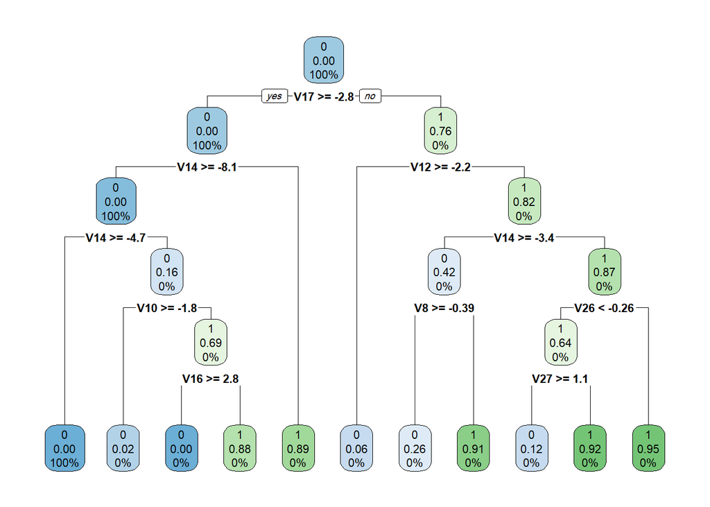

```r
rpart.plot(decisionTree_model)
```

#8.provide explanation?

As the above plot indicates the fraud boarder for each variable.